# A2_Seed_Point_Correlation

## Seed Point Correlation Method Demo

This script will show the usage of factory 'OI_Functions\Seed_Grid' Base on already read-in Raw R value matrix. Spatial Filter and blk concat etc shall be done before. If you bin, it also need to be done before the usage.

*Ver 0.24.07.1 'Squid'*

Before use, you need to get **raw R value (NOT dR/R)** matrix of graph,in shape(N_frame,height,width) You might also need to set a save folder, all results will be saved here.

```
Shape of Import R Value Frame:(30183, 256, 256).
```

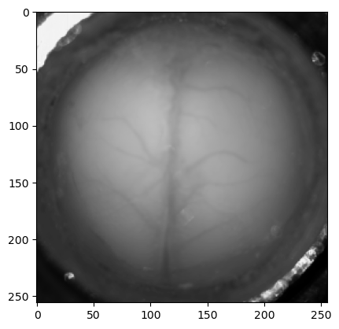

```python
#%% Import important pkg
import Common_Functions as cf
import numpy as np
import matplotlib.pyplot as plt
import warnings
from tqdm import tqdm
from Signal_Functions.Filters import Signal_Filter_1D
from scipy import stats
import seaborn as sns
# Import factory we use.
from OI_Functions.Seed_Grid import Seed_Correlation_Grid

# and folder of example data. Here we use an RF Data
wp = r'D:\YJX\spon_data\240719_RF_OIS_TEST\Run02_RF_VBar_20Hz_2ms\Preprocessed'
frames = np.load(cf.join(wp,'Red.npy'))

print(f'Shape of Import R Value Frame:{frames.shape}.')
plt.imshow(frames.mean(0),cmap = 'gist_gray')
```

Okay, then we will do bin for this data, as 20Hz is way too quick and have high noise.

We use bin=4, after this, the data shall be in 5Hz.

```python
binsize = 4

fps = 20/binsize # 4 binned 20Hz is 5Hz

binnum = frames.shape[0]//4 # ignore unfinished part
raw_R_frame = np.reshape(frames[:binnum*binsize,:,:],(binnum,binsize,frames.shape[1],frames.shape[2])).mean(1)

print(f'Size After Bin is:{raw_R_frame.shape}')
```

```
Size After Bin is:(7545, 256, 256)
```

### Here Comes the important part

#### Step1:Set the factory

You will have to define:

- Input R value frame
- fps of frame capture
- size of grid, you need to set each grids' pixel size
- save folder

```python
save_folder = r'D:\YJX\spon_data\240719_RF_OIS_TEST\Run02_RF_VBar_20Hz_2ms\Preprocessed\Seed_Tests'
# define class parameter
SCG = Seed_Correlation_Grid(frame=raw_R_frame,fps = fps,grid_size=8,save_folder=save_folder)

# you can real length of frame anytime by calling len(SCG)
print(f'Total input frame num:{len(SCG)}')
# you can get each single frame by given the id of it.
print(f'Single Frame Shape:{SCG[0].shape}')
```

```
Total input frame num:7545
Single Frame Shape:(256, 256)
```

#### Step2, cut gragh and define dR/R method.

Use function SCG.Grid_Cutter() to get grid response. Para explained below:

- clip: Clip of average graph, change visual effect only.
- font_size: size of grid annotation font. For different grid size, you need to change it to see number clearly.
- drr_method: *IMPORTANT*. We provide 2 way of getting dR/R. If it's set 'before', dR/R will be done on each pixel's time course, and add each grids' tc together; else if it's set 'after', we will add up all pixels in each grid, then do dR/R. As you can see, 'before' is always slower.
- save: bool. If set True, save gridded dR/R in savepath.

Grid dR/R will give you a cutted demo, you can choose seed through it.

```
Generating Grid graph, save at D:\YJX\spon_data\240719_RF_OIS_TEST\Run02_RF_VBar_20Hz_2ms\Preprocessed\Seed_Tests
```

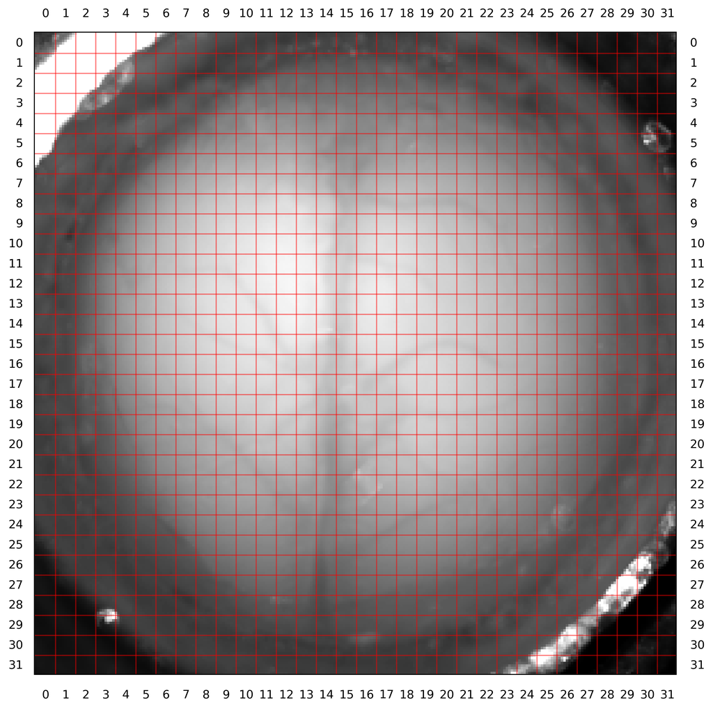

```
Grid Cutting Finished. You can select seed now.
Generating Grid dR/R Series.
Do dR/R After Averaging Grid.
```

```python
# para here are default paras. If you use default, no need to assign them agian, just run 'SCG.Grid_Cutter()'
SCG.Grid_Cutter(clip=2,font_size=10,drr_method = 'after',save = True)
```

#### Step3, set seed coordinates

After evaluation, you need to decide which point(or points are seeds), just put coordinate of seed grid(s) into function'SCG.Seed_Determine()'

*IMPORTANT:* Coordinates of seed grid shall be given in seq *Y,X*. and the seed must be given through a list, each element is a set of id.

```python
seed_coords = [(4,9),(4,10),(5,10)]
SCG.Seed_Determine(seed_coords)
```

```
Seed Number:3
```

#### Step4, generate correlation matrix

*IMPORTANT:* This step must be done after seed selection. Easy why.

Parameters:

- corr: Method of correlation.'Pearson' for pearson R and 'Spearman' for spearman R.
- HP & LP: High-pass and Low-pass filter of data. You can set it as False to skip.

After this operation, the correlation matrix is saved in SCG.Seed_Corr; P value of each compare are in SCG.Seed_Corr_p

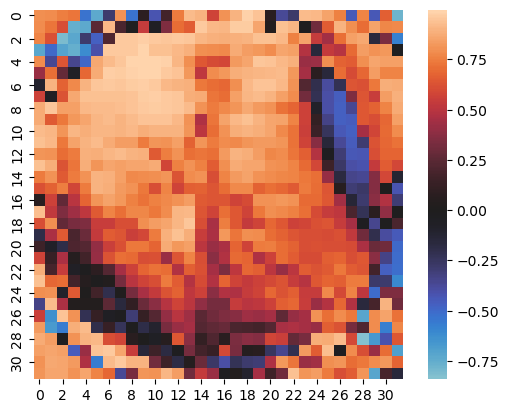

```python
# here we use default parameter.
SCG.Correlate_Grids('Pearson',HP = False,LP = False)

# plot correlation matrix toward seed point.
corr_mat = SCG.Seed_Corr
sig_mat = SCG.Seed_Corr_p
sns.heatmap(corr_mat,center = 0,square=True)
```

#### Step4 (Ver.b), Slide-window seed correlation.

If you think the correlation might change through time, we provide you a slide-window method in function 'SCG.Correlate_Grid_Slide_Window()' You need to set the window length and window step. Both need to be given in *Seconds*

The result is saved in 'SCG.Seed_Corr_Win' and 'SCG.Seed_Corr_Win_p'.Both is a 3D matrix, in seq(win_number,grid_vertical,grid_horizontal)

```
Shape of slide window correlation:(48, 32, 32)
```

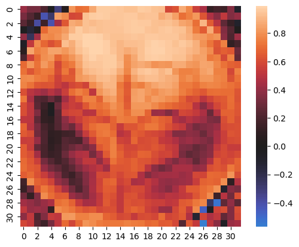

```python
SCG.Correlate_Grid_Slide_Window(win_len = 90,win_step = 30,LP=False,HP=False)

corr_win_mat = SCG.Seed_Corr_Win
sig_win_mat = SCG.Seed_Corr_Win_p

print(f'Shape of slide window correlation:{corr_win_mat.shape}')

# and we show an example corr frame.
sns.heatmap(SCG.Seed_Corr_Win[0,:,:],center = 0,square=True)
```

Save all slided windows in save path.

```
Folder D:\YJX\spon_data\240719_RF_OIS_TEST\Run02_RF_VBar_20Hz_2ms\Preprocessed\Seed_Tests\Slide_Window_Corrs already exists!
```

[figure not shown]

```python
# make subfolder
slide_path = cf.join(save_folder,'Slide_Window_Corrs')
cf.mkdir(slide_path)


# cycle time window.
vmax = 1
vmin = -0.8
for i in tqdm(range(len(SCG.Seed_Corr_Win))):
    c_graph = SCG.Seed_Corr_Win[i,:,:]
    plt.clf()
    plt.cla()
    fig,ax = plt.subplots(ncols=1,nrows=1,figsize = (5,5),dpi = 240)
    sns.heatmap(c_graph,xticklabels=False,yticklabels=False,square=True,ax = ax,center=0,vmax = vmax,vmin = vmin)
    fig.savefig(cf.join(slide_path,f'{10000+i}.png'))
    plt.close(fig)
```